# Evaluation d’un protocole de suivi de la Loutre d’Europe (Lutra lutra) à l’échelle d’un bassin versant en Bretagne

PabloVigneron

2025-06-16

```r
# Importation des packages
library(tidyverse)
library(gridExtra)
#library(lubridate)
library(sf)
library(mapview)
library(maptiles)
library(tidyterra)
library(kableExtra)
#library(knitr)
library(janitor)
library(RVAideMemoire)
library(emmeans)
library(car)
library(MASS)
library(lme4)
library(MuMIn)
#library(stringr)
library(stringi)
library(terra)
library(ggspatial)
library(slippymath)
library(rosm)
library(writexl)
library(ggpubr)
library(gridExtra)
```

```r
# Importation des données - Secteur J25 : Petit Tregor
base_tregor <-
  readxl::read_xlsx(path = '../raw_data/export_suiviloutrelocal_telecharger_csv_2025_04_03_10h58m17.xlsx') %>%
  dplyr::select(
    id_dataset,
    code_secteur,
    code_site,
    nom_site,
    x_l93,
    y_l93,
    date_visite,
    observateurs,
    condition_prospection,
    nom_taxon,
    nom_complet_taxon,
    techn_observation,
    statut_observation,
    nb_ep_tot,
    nb_ep_w,
    nb_ep_dnf,
    nb_ep_df
  ) %>%
  mutate(
    annee = year(date_visite),
    mois = month(date_visite),
    jour = day(date_visite),
    nb_ep_w = abs(nb_ep_w),
    statut_observation = ifelse(str_detect(statut_observation, '^Pr'), yes = 'Présent', no = 'Absent')
  ) %>%
  filter(nom_complet_taxon =='Lutra lutra',
         !(id_dataset == 85 & code_secteur == "FR5300006"),
         code_secteur != "J401",
         !(annee == 2022)) %>%
  dplyr::distinct(code_site, annee, .keep_all = T)
#=> Suppression de la valeur de 2022 qui est une erreur de saisie
```

```r
#tab_1 <- tribble(~"Comparaison", ~"n",
#                 "Identiques", "32")

#knitr::kable((tab_1), booktabs = TRUE,
##caption = 'A test table.')
```

```r
# Importation avec data 2025 - Lieue de Greve

base_greve_raw <-
  readxl::read_xls(path = '../raw_data/Suivi loutre mars_25.xls',
                   skip = 1,
                   col_names = T)
```

```r
# Export des bonnes coordonnées - Secteur Lieue de grève

site_lg <-
  readxl::read_xlsx(path = '../raw_data/coord_lieue_de_greve.xlsx', col_names = T) %>%
  dplyr::mutate(point_n = as.numeric(Ponts)) %>%
  dplyr::select(point_n, X_L93, Y_L93)
```

```r
## Correction des données - Mise en forme - Secteur : Lieu Greve avec data 2025

base_greve <- base_greve_raw %>%
  janitor::clean_names() %>%
  left_join(site_lg, by = "point_n") %>%
  dplyr::select(
    point_n,
    itineraire,
    X_L93,
    Y_L93,
    commune,
    cours_deau,
    bilan_choix_du_site,
    epreinte_oct20,
    date_suivi_fev_mars21,
    marquage_suivi_fev_mars21,
    date_suivi_oct21,
    marquage_suivi_oct21,
    observateurs_suivi_oct21,
    date_suivi_mars22,
    marquage_suivi_mars22,
    observateurs_suivi_mars22,
    date_suivi_decembre22,
    marquage_suivi_decembre22,
    observateurs_suivi_decembre22,
    date_suivi_mars23,
    marquage_suivi_mars23,
    observateurs_suivi_mars23,
    date_suivi_octobre_24,
    marquage_suivi_octobre_24,
    observateurs_suivi_octobre_24,
    date_suivi_mars_25,
    marquage_suivi_mars_25,
    observateurs_suivi_mars_25
  ) %>%
  dplyr::rename(
    code_site = point_n,
    x_l93 = X_L93,
    y_l93 = Y_L93,
    marquage_suivi_oct_20 = epreinte_oct20
  ) %>%
  dplyr::mutate(date_suivi_octobre_24 = as.Date(as.numeric(date_suivi_octobre_24), origin = "1899-12-30")) %>%
  dplyr::mutate(date_suivi_oct_20 = as.Date("2020-10-01")) %>%
  dplyr::mutate(across(
    c(
      date_suivi_fev_mars21,
      date_suivi_oct21,
      date_suivi_mars22,
      date_suivi_decembre22,
      date_suivi_mars23,
      date_suivi_oct_20,
      date_suivi_mars_25
    ),
    ~ as.POSIXct(.x)
  )) %>%
  mutate(across(starts_with("marquage_suivi_"), as.character)) %>%
  tidyr::pivot_longer(
    cols = c(
      date_suivi_oct_20,
      marquage_suivi_oct_20,
      date_suivi_fev_mars21,
      marquage_suivi_fev_mars21,
      date_suivi_oct21,
      marquage_suivi_oct21,
      observateurs_suivi_oct21,
      date_suivi_mars22,
      marquage_suivi_mars22,
      observateurs_suivi_mars22,
      date_suivi_decembre22,
      marquage_suivi_decembre22,
      observateurs_suivi_decembre22,
      date_suivi_mars23,
      marquage_suivi_mars23,
      observateurs_suivi_mars23,
      date_suivi_octobre_24,
      marquage_suivi_octobre_24,
      observateurs_suivi_octobre_24,
      date_suivi_mars_25,
      marquage_suivi_mars_25,
      observateurs_suivi_mars_25
    ),
    names_to = c(".value", "session"),
    names_pattern = "(date_suivi|marquage_suivi|observateurs_suivi)_(.*)"
  ) %>%
  rename(
    date_visite = date_suivi,
    statut_presence = marquage_suivi,
    observateurs = observateurs_suivi
  ) %>%
  dplyr::mutate(
    annee = year(date_visite),
    mois = month(date_visite),
    jour = day(date_visite),
    code_site = as.factor(code_site),
    statut_presence = case_when(
      tolower(statut_presence) == "oui" ~ 1,
      suppressWarnings(as.numeric(statut_presence)) >= 1 ~ 1,
      tolower(statut_presence) %in% c("non", "peut_etre") ~ 0,
      TRUE ~ 0
    ),
    statut_observation = ifelse(statut_presence == 1, "Présent", "Absent"),
    statut_presence = as.factor (statut_presence),
    jour = ifelse(jour == 1, NA, jour),
    annee = ifelse(annee == 2002, 2021, annee),
    y = str_replace_all(y_l93, ",", ""),
    x = str_replace_all(x_l93, " ", ""),
    passage = ifelse(mois <= 6, 1, 2),
    date_visite = ifelse(
      date_visite == as.Date("2002-02-24"),
      "2021-02-24",
      as.character(date_visite)
    ),
    observateurs_clean = observateurs %>%
      str_to_lower() %>%
      str_replace_all(" et ", "_") %>%
      str_replace_all("[[:space:]]+", "_") %>%
      str_replace_all("[^a-z0-9_]", "") %>%
      stri_trans_general("latin-ascii")
  ) %>%
  dplyr::mutate(observateurs_clean = as.factor(
    ifelse(
      observateurs_clean == "maxime_chapelle_romain_salaun",
      "maxime_chapelle_romain_salun",
      observateurs_clean
    )
  )) %>%
  dplyr::filter(!is.na(code_site), !is.na(itineraire))
```

```r
# Export jeu de donnée pour carte SIG
#readr::write_csv(base_greve,
 #                   path = "../processed_data/base_Lieue_de_greve.csv"
 #                   )
```

```r
# Export jeu de donnée pour carte SIG
#readr::write_csv(base_j25,
 #                   path = "../processed_data/base_Petit_tregor.csv"
   #                 )
```

**RESUME**

**Evaluation d’un protocole de suivi de la Loutre d’Europe (Lutra lutra) à l’échelle d’un bassin versant en Bretagne.**

Après une quasi-disparition au cours du XXe siècle, la Loutre d’Europe (Lutra lutra), a fait un retour de l’international jusqu’en Bretagne où elle a bien recolonisée grâce à la mise en place d’un statut de protection et la restauration de ses habitats. La présente étude a évalué un protocole destiné à un suivi local de l’espèce, à détecter des tendances temporelles et appliqué sur deux bassins versants bretons de 2011 à 2025. Le protocole, proposé initialement en Angleterre, est basé sur la recherche annuelle, sur 60 sites, des marquages de l’espèce utilisés comme indicateurs de présence. Un modèle linéaire généralisé mixte (GLMM) a été utilisé pour modéliser ces tendances temporelles et une approche de simulation de tendance basée sur le modèle nul a été réalisée pour tester la capacité du modèle à la détection de tendances temporelles. Les résultats montrent que le modèle GLMM n’a pas détecté de tendance et s’ajuste mal aux données. Toutefois, les simulations ont permis de détecter des tendances significatives à l’augmentation. L’étude met alors en lumière les difficultés des modèles utilisés à détecter des tendances significatives et à s’ajuster correctement aux jeux de données. Les simulations montrent des résultats intéressants qui méritent un approfondissement sachant que les dynamiques réelles y sont simplifiées. Pour conclure, le protocole de suivi semble pertinent, mais demande une application rigoureuse, dans une période suffisante en respectant la continuité des séries temporelles pour correctement estimer son efficacité.

Mots-clés : Loutre d’Europe - Suivi - Tendance temporelle - GLMM - Null Model - Simulation

**ABSTRACT**

**Evaluation of protocol for monitoring the European Otters (Lutra lutra) in a catchment area in Brittany.**

Key- words : Loutre d’Europe - Monitoring - Temporal trend - GLMM - Null Model - Simulation

# 1 INTRODUCTION

Malgré les politiques internationales pour tenter d’enrayer la crise d’érosion de la biodiversité, la perte d’espèces se poursuit à un rythme effréné pendant que les pressions sur celles-ci ne cessent d’augmenter (Butchart et al., 2010; Hochkirch et al., 2023). Le changement d’affectation des terres, la perte et dégradation d’habitats et la pollution constituent les principales causes d’extinction de la biodiversité selon l’IPBES, c’est typiquement le cas sur les mammifères terrestres européens (Díaz et al., 2019; Temple & Terry, 2009). Les carnivores représentent un des groupes cibles pour la conservation de la biodiversité par le rôle qu’ils occupent dans les écosystèmes (Fernández-Sepúlveda & Martín, 2022; Ritchie et al., 2012). Du fait de leur position haute dans la chaîne alimentaire, la protection de ces espèces dites “parapluies”, peut mener à la protection de nombreuses espèces voire d’écosystèmes tout entier (Roberge & Angelstam, 2004; Sergio et al., 2008). Pendant que certaines espèces de grands carnivores rétablissent leurs effectifs en Europe, l’état de menace de nombreuses populations de petits carnivores demeure très inquiétant (Chapron et al., 2014; Fernández-Sepúlveda & Martín, 2022). Un grand nombre de mustélidés sensibles aux activités anthropiques ont subi d’importants déclins durant ce dernier siècle (Chanin & Jefferies, 1978; Thompson, 1991; Wright et al., 2022). Cependant, la loutre d’Europe (Lutra lutra) représente un exemple rare et concret de rétablissement de populations de petit carnivore Mustelidae à l’échelle européenne (Lacombe et al., 2025). Au cours du XX e siècle, les populations de l’espèce ont chuté drastiquement dans la majeure partie de son aire de distribution, allant jusqu’à la moitié de son aire en France métropolitaine (Kuhn & Jacques, 2011). La forte diminution des populations de ce petit Mustelidae semi-aquatique s’explique par la chasse, la pollution, l’épuisement des ses ressources alimentaires et la perte de ses habitats (Loy et al., 2022). La mise en protection juridique avec l’inscription à l’annexe I de la CITES (1973) et à l’annexe II de la Convention de Berne (1979) a permis son retour à l’échelle internationale dans les années 90s (Lacombe et al., 2025). En France, l’interdiction de la chasse et du piégeage en 1972 a permis d’enrayer l’extinction de l’espèce (Grémillet & Simonnet, 2015; Kuhn & Jacques, 2011). Au cours des années 1990, une lente dynamique de recolonisation, probablement amorcée 15 à 20 ans plus tôt, est observée (Grémillet & Simonnet, 2015; Kuhn & Jacques, 2011). Cette dynamique s’expliquerait par l’inscription aux annexes II et IV de la Directive Habitats Faune Flore de 1992, mais aussi à l’amélioration de la qualité des cours d’eau avec la directive cadre sur l’eau (DCE) (Kuhn & Jacques, 2011). En trois décennies, la loutre a triplé son aire de répartition en Bretagne, occupant près de 60 % des bassins versants (Grémillet & Simonnet, 2015). La recolonisation s’est faite en “tâches d’huiles” à partir des noyaux de populations restants, par les têtes de bassin versant (Grémillet & Simonnet, 2015). C’est pourquoi l’espèce est aujourd’hui menacée par les collisions routières avec le développement du réseau routier (Kuhn & Jacques, 2011). Ce mustelidae a une telle dynamique qu’on le retrouve dans des cours d’eau de mauvaise qualité (i.e. qualité d’eau et biomasse piscicole) ainsi qu’en milieu urbain, alors qu’il était auparavant considéré comme indicateur de bonne qualité d’eau (Grémillet & Simonnet, 2015). Tant que l’espèce trouve, dans un milieu, des ressources alimentaires ainsi que des gîtes en quantité suffisante, elle peut s’y installer (Grémillet & Simonnet, 2015). En Bretagne, elle fréquente les ruisseaux salmonicoles aux ripisylves denses et naturelles mais également les cours d’eau cyprinicoles, les plans d’eau, les marais littoraux et estuaires (Grémillet & Simonnet, 2015). Les ressources trophiques de l’espèce sont principalement composées de poissons mais elle reste opportuniste et consomme aussi des amphibiens et écrevisses et occasionnellement de petits oiseaux et mammifères (Clavero et al., 2003; Mirone et al., 2024). Bien que de récents travaux montrent que le rétablissement de l’espèce est un succès pour la conservation des petits carnivores, il faut considérer son retour définitif en Bretagne avec prudence (Grémillet & Simonnet, 2015; Lacombe et al., 2025). Le second plan national d’actions (PNA) de la loutre d’europe (2019-2028) visant à favoriser le retour de l’espèce dans son aire de répartition originelle est actuellement en cours (Kuhn et al., 2019). Suivre les espèces est indispensable pour dégager des tendances populationnelles et orienter des mesures de conservation (Jones, 2011). Les programmes de suivi d’espèces sont coûteux en ressources et les scientifiques chargés de la conservation chercheront toujours à trouver un compromis en utilisant des méthodes ayant un bon rapport coût-efficacité, pour investir le reste dans d’autres actions (Murray et al., 2009). Néanmoins, la validation des méthodes de suivi peu coûteuses en donnée par rapport à des méthodes demandant beaucoup plus de données, est souvent négligée alors qu’elle représente une étape cruciale pour éviter de gaspiller de l’investissement en ressources (De Barba et al., 2010; Jones et al., 2008; Legg & Nagy, 2006). Dans ce sens, préalablement à la mise en place d’un programme de suivi, il est préférable d’estimer la puissance statistique nécessaire à l’analyse pour éviter d’avoir des résultats peu robustes ou de penser que le travail effectué a posteriori à servi à quelque chose (Legg & Nagy, 2006). La dynamique nationale et régionale est aussi d’améliorer la connaissance de la répartition de la Loutre d’Europe et suivre l’évolution et la dynamique de sa recolonisation pour contribuer à l’évaluation de son statut de conservation et d’identifier les menaces et contraintes locales (Kauffmann et al., 2024). Le suivi actuel de la loutre en Bretagne se fait selon le protocole standard du groupe loutre de l’UICN appliqué également au niveau national, parfois adapté et par des données ponctuelles d’observateurs d’un réseau de veille (Grémillet & Simonnet, 2015; Reuther et al., 2000). Comme la loutre est discrète et difficile à observer en plein jour, ce protocole standard se base sur des indices de présence (Kauffmann et al., 2024). Il se base sur le comportement de marquage qui se traduit par le dépôt d’urine et de crottes appelées épreintes, mêlées à des sécrétions anales, reconnaissables à leur odeur suave ou mielleuse (Kuhn & Jacques, 2011). Ce comportement a une double fonction, répulsive en marquant son territoire vis à vis des autres individus et attractive pour la recherche de partenaire sexuel (Kuhn & Jacques, 2011). Ces épreintes sont de bons indicateurs de présence de l’espèce et sont retrouvées la plupart du temps sur des sites de marquages traditionnels, qui sont visités plus ou moins régulièrement et remarqués avec un fréquence allant de 18 jours à 4 mois (Kuhn & Jacques, 2011; Lodé, 1995). Un autre protocole également basé sur le comportement de marquage a été mis au point pour suivre les populations de Loutre d’Europe (Lutra lutra) au sein du réseau Natura 2000 du Royaume-Uni dans le cadre du Life in UK Rivers Projects (Chanin, 2003, 2005). Cette méthode se focalise sur la prospection des ponts ou passerelles qui représentent des points stratégiques de marquage pour l’espèce. Il aurait l’avantage d’être relativement peu coûteux en temps de prospection (Chanin, 2003; Kauffmann et al., 2024). En outre, cette méthode serait complémentaire d’un suivi régional et s’appliquerait à l’échelle plus locale d’un bassin versant et permettrait donc de détecter des tendances fines. Comme il est préférable d’évaluer une méthode de suivi avant de la mettre en place en routine sur un long terme, la présente étude a pour objet d’évaluer l’efficacité de cette méthode en se basant sur un test de suivi réalisé par le Groupe Mammalogique Breton (GMB) en Bretagne, sur deux bassins versants entre la baie de Lannion et de Morlaix (Legg & Nagy, 2006). Plus précisément, la présente étude vise à évaluer si le protocole permet de détecter des tendances temporelles chez la Loutre d’Europe (Lutra lutra) à l’échelle d’un bassin versant. Cette tendance à été modélisée dans un premier temps, à partir d’un modèle linéaire généralisé mixte (GLMM). Une approche de simulation de tendance basée sur des permutations inspirées du modèle nul ont été réalisées dans un second temps (Gotelli & Entsminger, 2001; N. W. H. Mason et al., 2007). Ces simulations ont pour principal objectif de tester la “robustesse” du modèle GLMM pour la détection de tendances temporelles.

# 2 MATERIELS ET METHODES

## 2.1 Source de données

Les données ont été transmises par le GMB. Les données du secteur “Petit Trégor” ont été acquises par les étudiants et étudiantes en BTS Gestion et Protection de la Nature (GPN) du Lycée agricole de Morlaix-Suscinio dans le Finistère (29). Les données du secteur “Lieue de Grève” ont été acquises par le personnel (conservateurs, stagiaires et service civique) de la Réserve naturelle régionale (RNR) des “Landes, prairies et étangs de Plounérin” dans le département des Côtes d’Armor (22), gérée par Lannion-Trégor Communauté.

## 2.2 Echantillonnage

L’échantillonnage se base sur les travaux de Paul Chanin qui a mis au point un protocole pour suivre les populations de Loutre d’Europe (Lutra lutra) au sein du réseau Natura 2000 du Royaume-Uni dans le cadre du Life in UK Rivers Projects (Chanin, 2003, 2005). Les principaux objectifs visés du protocole sont, d’une part de surveiller la distribution des loutres dans les Zone Spéciale de Conservation (ZSC) en cherchant la présence de marquage à l’échelle d’un bassin-versant et d’autre part de détecter des modifications dans l’habitat de l’espèce (i.e. disponibilité en ressources alimentaires). Secteurs d’études

## 2.3 Secteurs d’études

La présente étude se base sur des données récoltées en Bretagne à la frontière entre le département du Finistère (29) et des Côtes d’Armor (22) (Fig 1). Le premier site d’étude “Petit Trégor” est situé sur les bassins-versants de “Trégor” et du “Côtiers du Trégor” entre la baie de Morlaix et de Lannion dans le Finistère (29) (INRAE, n.d.). Le second site d’étude “Lieue de Grève” est situé sur le bassin versant de la “Lieue de Grève” entre la baie de Morlaix et de Lannion dans les Côtes d’Armor (22) (INRAE, n.d.).

```r
# Représentation cartographique du secteur d'étude et des sites correspondants

sites_geo_1 <- base_greve %>%
  mutate(
    code_secteur = "J22",
    y = str_replace_all(y, ",", "."),
    x = str_replace_all(x, ",", "."),
    y = as.numeric(y),
    x = as.numeric(x)
  ) %>%
  filter(!is.na(x) & !is.na(y)) %>%
  rename(nom_site = commune) %>%
  dplyr::select(nom_site, code_site, code_secteur, statut_observation, annee, x_l93, y_l93) %>%
  st_as_sf(coords = c("x_l93", "y_l93"), crs = 2154)


sites_geo_2 <- base_tregor %>%
  filter(code_secteur == "J25") %>%
  dplyr::select(nom_site:y_l93, code_site, code_secteur, statut_observation, annee) %>%
  st_as_sf(coords = c("x_l93", "y_l93"), crs = 2154)

common_cols <- dplyr::intersect(names(sites_geo_1), names(sites_geo_2))

sites_geo <- bind_rows(
  sites_geo_1[, common_cols],
  sites_geo_2[, common_cols]
)

mapview(sites_geo, zcol = "code_secteur", col.regions = c("darkseagreen3", "indianred1"))
```

[interactive chart not shown]

### 2.3.1 Mise en place du réseau de site

Une étude préliminaire a été nécessaire pour définir chaque secteur d’étude correspondant à une section ou un sous-bassin-versant en repérant 80 à 100 sites d’études. Chaque site est situé au niveau d’un pont, d’un gué ou d’une passerelle appropriés au marquage de l’espèce (i.e. épreintes et empreintes). Selon ce protocole, parmi ces sites, en fonction des secteurs, 60 ont été sélectionnés. Les sites situés sur des terrains privés ont préférablement été évités. La facilité d’accès de ces sites a également été prise en compte pour leur sélection. La prospection est réalisée sous les ponts, gués ou passerelles ainsi que sur les berges adjacentes. Si aucun indice de présence n’a été trouvé (i.e. épreintes ou empreintes), la recherche s’étend à 50 m de chaque côté du pont, avec l’utilisation de jumelles si inaccessibles. La présence ou l’absence d’indice de présence de la loutre d’Europe sont relevées. Pour l’ensemble des sites, une fiche descriptive est réalisée, comportant les coordonnées GPS, le lieu de stationnement, la facilité d’accès, des photographies des lieux, l’endroit où des indices de présence de l’espèce sont observés. Ces fiches permettent aux observateurs et observatrices de faciliter l’échantillonnage les années suivantes. Les 60 sites ont été sélectionnés parmi la liste et constituent ceux qui ont été prospectés les années suivantes.

### 2.3.2 Suivis temporels.

```r
base_j25 <- base_j25 %>%
  mutate(annee = year(date_visite))

# Définir la plage complète d'années à afficher
annees_completes <- 2010:2023  # modifie cette plage si nécessaire

# Toutes les combinaisons site x année
all_combos <- expand_grid(
  code_site = unique(base_j25$code_site),
  annee = annees_completes
)

# Joindre et ajouter les statuts finaux
obs_complete <- all_combos %>%
  left_join(
    base_j25 %>% dplyr::select(code_site, annee, statut_observation),
    by = c("code_site", "annee")
  ) %>%
  mutate(
    statut_final = case_when(
      statut_observation == "Présent" ~ "Présent",
      statut_observation == "Absent" ~ "Absent",
      TRUE ~ "Non prospecté"
    )
  )

# Créer le graphique
suivi_tregor <- ggplot(obs_complete, aes(x = annee, y = code_site, fill = statut_final)) +
  geom_tile(color = "white", linewidth = 0.3) +
  scale_fill_manual(
    values = c(
      "Présent" = "darkseagreen3",
      "Absent" = "indianred1",
      "Non prospecté" = "grey80"
    )
  ) +
  labs(x = "Année",
       y = "Site",
       title = "Secteur Petit Trégor",
       fill = "Statut d'observation") +
  theme_minimal() +
  theme(
    plot.title = element_text(hjust = 0.5, face = "bold"),
    panel.border = element_rect(color = "black", fill = NA),
    legend.background = element_rect(fill = "grey95", color = "black"),
    axis.text.y = element_text(size = 8)  # au besoin, adapte la taille de texte
  )
```

```r
base_greve_spring <- base_greve %>%
  dplyr::filter(passage == 1)

annees_completes <- 2020:2025

all_combos <- expand_grid(
  code_site = unique(base_greve_spring$code_site),
  annee = annees_completes
)

obs_complete <- all_combos %>%
  left_join(
    base_greve_spring %>%
      dplyr::select(code_site, annee, statut_observation),
    by = c("code_site", "annee")
  ) %>%
  dplyr::mutate(
    statut_final = case_when(
      statut_observation == "Présent" ~ "Présent",
      statut_observation == "Absent" ~ "Absent",
      TRUE ~ "Non prospecté"
    )
  )

suivi_printemps <- ggplot(obs_complete, aes(x = annee, y = code_site, fill = statut_final)) +
  geom_tile(color = "white", linewidth = 0.3) +
  scale_fill_manual(values = c(
    "Présent" = "darkseagreen3",
    "Absent" = "indianred1",
    "Non prospecté" = "grey80"
  )) +
  labs(x = "Année",
       y = "Site",
       title = "Lieue greve, 1er passage",
       fill = "Statut d'observation") +
  theme_minimal() +
  theme(
    plot.title = element_text(hjust = 0.5, face = "bold"),
    panel.border = element_rect(color = "black", fill = NA),
    legend.background = element_rect(fill = "grey95", color = "black")
  )
```

```r
base_greve_winter <- base_greve %>%
  dplyr::filter(passage == 2)

annees_completes <- 2020:2024

all_combos <- expand_grid(
  code_site = unique(base_greve_winter$code_site),
  annee = annees_completes
)

obs_complete <- all_combos %>%
  left_join(
    base_greve_winter %>%
      dplyr::select(code_site, annee, statut_observation),
    by = c("code_site", "annee")
  ) %>%
  dplyr::mutate(
    statut_final = case_when(
      statut_observation == "Présent" ~ "Présent",
      statut_observation == "Absent" ~ "Absent",
      TRUE ~ "Non prospecté"
    )
  )

suivi_hiver <- ggplot(obs_complete, aes(x = annee, y = code_site, fill = statut_final)) +
  geom_tile(color = "white", linewidth = 0.3) +
  scale_fill_manual(values = c(
    "Présent" = "darkseagreen3",
    "Absent" = "indianred1",
    "Non prospecté" = "grey80"
  )) +
  labs(x = "Année",
       y = "Site",
       title = "Lieue greve, 2e passage",
       fill = "Statut d'observation") +
  theme_minimal() +
  theme(
    plot.title = element_text(hjust = 0.4, face = "bold"),
    panel.border = element_rect(color = "black", fill = NA),
    legend.background = element_rect(fill = "grey95", color = "black"),
    axis.text.y = element_text(size = 8))
```

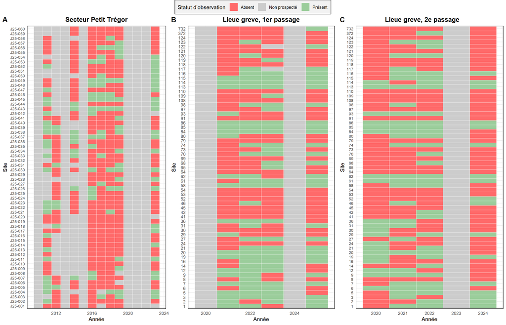

Figure 1: Statut d’observation (présence/absence) de la Loutre d’Europe sur les sites prospectées par secteurs d’études en fonction des années : (A) secteur Petit Trégor; (B) secteur de la Lieue de Grève, passage printanier et (C) secteur de la Lieue de Grève, passage automne-hiver

```r
fig_suivi_2 <- ggarrange(suivi_tregor, suivi_printemps,suivi_hiver,
                       labels = c("A", "B", "C"),
                    ncol = 3, nrow = 1,
                    common.legend = TRUE)
                   # layout_matrix = rbind(c(1,NA,3), c(NA,2,NA)))

fig_suivi_2
```

## 2.4 Mise en forme des données

Les données ont été mises en forme sous le logiciel de statistiques (V.4.1.1) (R Core Team, 2024) au moyen des packages : tidyverse, tidyterra, janitor et stringi.

## 2.5 Analyses statistiques

L’objectif de l’analyse de cette étude est double. En effet, le premier objectif de l’analyse est de déterminer si le protocole mis en œuvre permet de détecter une tendance temporelle. Le second objectif était de mettre en évidence une éventuelle tendance temporelle de la Loutre d’Europe sur les jeux de données de chacun des secteurs concernés. Si la nature du jeu de données est spatio-temporelle, l’analyse porte sur l’effet temporel de la présence de l’espèce.

### 2.5.1 Modélisation.

Pour mettre en évidence la relation entre la présence de la loutre d’Europe et l’année, un modèle linéaire généralisé mixte (GLMM) a été utilisé. La variable réponse étant qualitative binaire (présence/absence), la distribution de celle-ci est binomiale et la fonction de lien choisie est “logit” (modèle dit standard). Pour le secteur “Lieue de Grève”, l’effet passage catégorisé “passage printemps” et “passage automne-hiver” à été intégrée en facteur fixe au modèle en raison des passages réalisés à des saisonnalités différentes. Pour interpréter la significativité des effets, un test de Wald (χ²) a été réalisé en fixant le risque α à 5% (i.e. p-value <0,05). Il est important de préciser que les séries sont appariées. En effet, les données étant récoltées chaque année sur les mêmes sites, les observations ne sont donc pas indépendantes. Ceci suggère l’intégration d’un facteur aléatoire dans l’analyse. C’est la variabilité spatiale du marquage par l’espèce entre les 60 sites du bassin versant qui a été considérée comme un facteur aléatoire. Malgré ça, l’autocorrélation spatiale a été négligée dans l’analyse. Avant l’interprétation des résultats du modèle, pour vérifier l’ajustement du modèle aux données, l’indépendance des résidus du modèle avec les valeurs prédites à été vérifiée. Le modèle ne s’ajustant pas correctement aux jeux de données, d’autres fonctions de lien (“probit” et “cauchit”) ont été testées (Bolker et al., 2009). Aucune amélioration de l’ajustement n’a été observée. Aucune amélioration n’a été observée en considérant l’année en facteur, ni en intégrant l’effet observateur au modèle pour le secteur de la Lieue de grève. L’ajout de cette variable a complexifié le modèle mais n’a pas permis d’améliorer et d’avoir un ajustement correct du modèle aux données. Une grande prudence quant à l’interprétation des résultats de l’analyse des modèles GLMM est à prendre au vu de la faiblesse de l’ajustement du modèle aux données.

### 2.5.2 Simulation

Une approche complémentaire a été utilisée pour déterminer la “robustesse” de la détection des tendances par le modèle GLMM dit standard.

Pour répondre à la question, dans un premier temps une approche par permutation randomisée a été utilisée uniquement sur le jeu de données “Petit Trégor” en s’inspirant de travaux sur le modèle nul (Gotelli & Entsminger, 2001; N. W. H. Mason et al., 2007). Cette approche permet d’éliminer les tendances dans le jeu de données. Comme la présence ou non d’une tendance interannuelle dans les données était inconnue, la variable “année” du tableau de données a été permutée aléatoirement, toutes les autres colonnes restant inchangées. La permutation a été réalisée par site, afin de conserver une des caractéristiques essentielles du jeu de données qui est la période sur laquelle chaque site a été contrôlé. On obtient ainsi un jeu de données en tout point identique au jeu de donné initial, sauf que le potentiel signal interannuel a été effacé.

Dans un deuxième temps, une tendance temporelle connue a été introduite dans le jeu de données permuté. Cette tendance, simplifiée, est une tendance arithmétique à la croissance positive, en ajoutant une détection par année (i.e. une absence est transformée en présence) qui sera randomisé chaque année, autrement dit le site qui devient positif peut ne pas l’être l’année suivante. Il est important de souligner que le taux d’occupation de la loutre sur l’ensemble du jeu de données a été augmenté artificiellement avec la tendance introduite. On obtient ainsi un tableau de données dont on sait qu’il correspond à une population en croissance. Ce tableau va nous permettre d’estimer la capacité du modèle GLMM (traitée dans la partie modélisation), à détecter une tendance connue. Dans un troisième temps, la démarche a été renouvelée une centaine de fois pour estimer la “robustesse” du résultat avec la fonction suivante : tester tendances ( ). Cette fonction nécessite : un jeu de donnée, la tendance (i.e. nombre de présences à rajouter par année) et le nombre de permutations aléatoires à effectuer (fixé à 10 par défaut). Elle retourne un dataframe résumant l’effet “année” des modèles construits à chaque permutation. La fonction va effectuer les tâches suivantes une centaine de fois et compiler les résultats : Permutations des années pour gommer le signal Ajout de présences (tendance positive) dans le jeu de donnée permuté Exécution du modèle GLMM avec le jeu de donnée permutée dont une tendance à été introduite : statut de présence ~ année + (1 | site) Récupération de la pente (coefficient) associée à l’année et de la p-value associée du modèle GLMM

L’ensemble des analyses ont été effectuées sur le logiciel de statistique (R Core Team, 2024) avec les packages suivants : lme4, RVAideMemoire, MuMIn et car. La seed 123 de la fonction de R set.seed ( ) à été utilisée. Selon le principe FAIR (Findable, Accessible, Interoperable, Reusable) en science, pour assurer la reproductibilité de l’analyse, l’ensemble des scripts et des données brutes ont été rendus disponible en accès libre sur la plateforme github (Horton et al., 2022; Wilkinson et al., 2016) : https://github.com/PabloVigneron/Suivi_loutre .

# 3 RESULTATS

# 4 DISCUSSION

## 4.2 Simulation tendances temporelles

# 5 CONCLUSION

L’étude a mis en lumière les difficultés des modèles utilisés à détecter des tendances significatives et à s’ajuster aux jeux de données. L’approche de simulation a quant à elle montré des résultats intéressants et encourageants en montrant la “robustesse” du modèle à détecter des tendances à l’augmentation bien que des problèmes d’ajustement aux données subsistent. Pour améliorer l’ajustement du modèle, la prise en compte de l’autocorrélation spatiale dans de futures analyses ferait sens au même titre qu’une évaluation de la probabilité de détection et de l’ajout de variables explicatives alliées à de la sélection de modèle. Enfin, le protocole semble pertinent pour le suivi de la Loutre, mais demande une application rigoureuse dans la continuité des séries temporelles et sur un pas de temps suffisant pour vraiment estimer son efficacité.

# 6 REFERENCES BIBLIOGRAPHIQUES